# Expansión de la CASEN sobre el CENSO (Región 13)

P17 ¿Trabajó por un pago o especie?: Correlación: 0.8717

VE-CC-AJ

DataIntelligence

date: 20-07-2021

# 1 Resumen

Expandiremos los ingresos promedios (multiplicación del ingreso promedio y los habitantes) obtenidos de la CASEN 2017 sobre la categoría de respuesta: “Trabajó por un pago o especie” del campo P17 del CENSO de viviendas -del 2017-, que fue la categoría de respuesta que más alto correlacionó con los ingresos expandidos, ambos a nivel comunal.

Haremos el análisis sobre la región 13.

Ensayaremos diferentes modelos dentro del análisis de regresión cuya variable independiente será: “frecuencia de población que posee la variable Censal respecto a la zona” y la dependiente: “ingreso expandido por zona por proporción zonal a nivel comunal (**multipob**)”

Lo anterior para elegir el que posea el mayor coeficiente de determinación y así contruir una tabla de valores predichos.

# 2 Generación de ingresos expandidos a nivel Urbano

En adelante sólo llamaremos al rds ya construído llamado “Ingresos_expandidos_urbano_17.rds”

## 2.1 Variable CENSO

Necesitamos calcular las frecuencias a nivel censal de las respuestas correspondientes a la categoría: “Trabajó por un pago o especie” del campo **P17** del Censo de personas. Recordemos que ésta fué la más alta correlación en relación a los ingresos expandidos [(ver punto 2 Correlaciones aquí)](https://rpubs.com/dataintelligence/corr_ce_ca_P17).

### 2.1.1 Lectura y filtrado de la tabla censal de personas

Leemos la tabla Censo 2017 de personas que ya tiene integrada la clave zonal:

```r
tabla_con_clave <-
readRDS("../../../ds_correlaciones_censo_casen/corre_ing_exp-censo_casen/censos_con_clave/censo_personas_con_clave_17")
r3_100 <- tabla_con_clave[c(1:100),]
kbl(r3_100) %>%
  kable_styling(bootstrap_options = c("striped", "hover")) %>%
  kable_paper() %>%
  scroll_box(width = "100%", height = "300px")
```

| REGION | PROVINCIA | COMUNA | DC | AREA | ZC_LOC | ID_ZONA_LOC | NVIV | NHOGAR | PERSONAN | P07 | P08 | P09 | P10 | P10COMUNA | P10PAIS | P11 | P11COMUNA | P11PAIS | P12 | P12COMUNA | P12PAIS | P12A_LLEGADA | P12A_TRAMO | P13 | P14 | P15 | P15A | P16 | P16A | … |
| --- | --- | --- | --- | --- | --- | --- | --- | --- | --- | --- | --- | --- | --- | --- | --- | --- | --- | --- | --- | --- | --- | --- | --- | --- | --- | --- | --- | --- | --- | --- |
| 15 | 152 | 15202 | 1 | 2 | 6 | 13225 | 1 | 1 | 1 | 1 | 1 | 73 | 1 | 98 | 998 | 3 | 15101 | 998 | 1 | 98 | 998 | 9998 | 98 | 2 | 4 | 6 | 2 | 1 | 2 | … |
| 15 | 152 | 15202 | 1 | 2 | 6 | 13225 | 3 | 1 | 1 | 1 | 1 | 78 | 1 | 98 | 998 | 2 | 98 | 998 | 1 | 98 | 998 | 9998 | 98 | 3 | 98 | 98 | 98 | 1 | 2 | … |
| 15 | 152 | 15202 | 1 | 2 | 6 | 13225 | 3 | 1 | 2 | 2 | 2 | 78 | 1 | 98 | 998 | 2 | 98 | 998 | 1 | 98 | 998 | 9998 | 98 | 3 | 98 | 98 | 98 | 1 | 2 | … |
| 15 | 152 | 15202 | 1 | 2 | 6 | 13225 | 3 | 1 | 3 | 5 | 2 | 52 | 1 | 98 | 998 | 2 | 98 | 998 | 1 | 98 | 998 | 9998 | 98 | 1 | 2 | 5 | 2 | 1 | 2 | … |
| 15 | 152 | 15202 | 1 | 2 | 6 | 13225 | 3 | 1 | 4 | 11 | 1 | 44 | 1 | 98 | 998 | 2 | 98 | 998 | 1 | 98 | 998 | 9998 | 98 | 1 | 3 | 5 | 2 | 1 | 2 | … |
| 15 | 152 | 15202 | 1 | 2 | 6 | 13225 | 9 | 1 | 1 | 1 | 1 | 39 | 1 | 98 | 998 | 2 | 98 | 998 | 1 | 98 | 998 | 9998 | 98 | 2 | 8 | 5 | 1 | 1 | 2 | … |
| 15 | 152 | 15202 | 1 | 2 | 6 | 13225 | 9 | 1 | 2 | 2 | 2 | 35 | 1 | 98 | 998 | 2 | 98 | 998 | 1 | 98 | 998 | 9998 | 98 | 2 | 6 | 5 | 2 | 1 | 2 | … |
| 15 | 152 | 15202 | 1 | 2 | 6 | 13225 | 9 | 1 | 3 | 5 | 1 | 13 | 1 | 98 | 998 | 2 | 98 | 998 | 1 | 98 | 998 | 9998 | 98 | 1 | 7 | 5 | 2 | 1 | 2 | … |
| 15 | 152 | 15202 | 1 | 2 | 6 | 13225 | 9 | 1 | 4 | 5 | 1 | 12 | 1 | 98 | 998 | 2 | 98 | 998 | 1 | 98 | 998 | 9998 | 98 | 1 | 6 | 5 | 2 | 1 | 2 | … |
| 15 | 152 | 15202 | 1 | 2 | 6 | 13225 | 10 | 1 | 1 | 1 | 2 | 65 | 1 | 98 | 998 | 2 | 98 | 998 | 1 | 98 | 998 | 9998 | 98 | 2 | 4 | 5 | 2 | 1 | 2 | … |
| 15 | 152 | 15202 | 1 | 2 | 6 | 13225 | 13 | 1 | 1 | 1 | 1 | 50 | 1 | 98 | 998 | 2 | 98 | 998 | 1 | 98 | 998 | 9998 | 98 | 2 | 5 | 5 | 2 | 1 | 2 | … |
| 15 | 152 | 15202 | 1 | 2 | 6 | 13225 | 13 | 1 | 2 | 4 | 2 | 43 | 1 | 98 | 998 | 2 | 98 | 998 | 1 | 98 | 998 | 9998 | 98 | 2 | 6 | 5 | 2 | 1 | 2 | … |
| 15 | 152 | 15202 | 1 | 2 | 6 | 13225 | 13 | 1 | 3 | 5 | 1 | 15 | 3 | 15201 | 998 | 2 | 98 | 998 | 1 | 98 | 998 | 9998 | 98 | 1 | 1 | 7 | 2 | 1 | 2 | … |
| 15 | 152 | 15202 | 1 | 2 | 6 | 13225 | 16 | 1 | 1 | 1 | 1 | 75 | 1 | 98 | 998 | 2 | 98 | 998 | 1 | 98 | 998 | 9998 | 98 | 3 | 98 | 98 | 98 | 1 | 2 | … |
| 15 | 152 | 15202 | 1 | 2 | 6 | 13225 | 16 | 1 | 2 | 16 | 2 | 58 | 4 | 98 | 68 | 6 | 98 | 998 | 5 | 98 | 998 | 9999 | 1 | 3 | 98 | 98 | 98 | 1 | 2 | … |
| 15 | 152 | 15202 | 1 | 2 | 6 | 13225 | 16 | 1 | 3 | 2 | 2 | 70 | 1 | 98 | 998 | 2 | 98 | 998 | 1 | 98 | 998 | 9998 | 98 | 3 | 98 | 98 | 98 | 1 | 2 | … |
| 15 | 152 | 15202 | 1 | 2 | 6 | 13225 | 17 | 1 | 1 | 1 | 2 | 43 | 2 | 98 | 998 | 2 | 98 | 998 | 1 | 98 | 998 | 9998 | 98 | 2 | 8 | 5 | 1 | 1 | 2 | … |
| 15 | 152 | 15202 | 1 | 2 | 6 | 13225 | 17 | 1 | 2 | 4 | 1 | 55 | 2 | 98 | 998 | 2 | 98 | 998 | 1 | 98 | 998 | 9998 | 98 | 2 | 6 | 5 | 2 | 1 | 2 | … |
| 15 | 152 | 15202 | 1 | 2 | 6 | 13225 | 17 | 1 | 3 | 5 | 2 | 13 | 2 | 98 | 998 | 2 | 98 | 998 | 2 | 15101 | 998 | 9998 | 98 | 1 | 7 | 5 | 2 | 1 | 2 | … |
| 15 | 152 | 15202 | 1 | 2 | 6 | 13225 | 17 | 1 | 4 | 5 | 1 | 8 | 2 | 98 | 998 | 2 | 98 | 998 | 2 | 15101 | 998 | 9998 | 98 | 1 | 2 | 5 | 2 | 1 | 2 | … |
| 15 | 152 | 15202 | 1 | 2 | 6 | 13225 | 17 | 1 | 5 | 15 | 2 | 29 | 2 | 98 | 998 | 4 | 98 | 998 | 3 | 98 | 998 | 2015 | 1 | 2 | 6 | 5 | 2 | 1 | 2 | … |
| 15 | 152 | 15202 | 1 | 2 | 6 | 13225 | 17 | 1 | 6 | 15 | 1 | 4 | 2 | 98 | 998 | 1 | 98 | 998 | 5 | 98 | 998 | 2015 | 1 | 1 | 0 | 1 | 2 | 1 | 2 | … |
| 15 | 152 | 15202 | 1 | 2 | 6 | 13225 | 17 | 1 | 7 | 15 | 2 | 2 | 2 | 98 | 998 | 1 | 98 | 998 | 3 | 98 | 998 | 2015 | 1 | 1 | 0 | 1 | 2 | 1 | 2 | … |
| 15 | 152 | 15202 | 1 | 2 | 6 | 13225 | 17 | 1 | 8 | 15 | 1 | 16 | 2 | 98 | 998 | 6 | 98 | 998 | 1 | 98 | 998 | 9998 | 98 | 2 | 4 | 5 | 2 | 1 | 2 | … |
| 15 | 152 | 15202 | 1 | 2 | 6 | 13225 | 18 | 1 | 1 | 1 | 2 | 74 | 1 | 98 | 998 | 2 | 98 | 998 | 1 | 98 | 998 | 9998 | 98 | 2 | 2 | 5 | 2 | 1 | 2 | … |
| 15 | 152 | 15202 | 1 | 2 | 6 | 13225 | 19 | 1 | 1 | 1 | 1 | 68 | 1 | 98 | 998 | 2 | 98 | 998 | 1 | 98 | 998 | 9998 | 98 | 3 | 98 | 98 | 98 | 1 | 2 | … |
| 15 | 152 | 15202 | 1 | 2 | 6 | 13225 | 20 | 1 | 1 | 1 | 1 | 74 | 1 | 98 | 998 | 3 | 15101 | 998 | 1 | 98 | 998 | 9998 | 98 | 2 | 2 | 5 | 2 | 1 | 2 | … |
| 15 | 152 | 15202 | 1 | 2 | 6 | 13225 | 20 | 1 | 2 | 2 | 2 | 65 | 1 | 98 | 998 | 3 | 997 | 998 | 3 | 98 | 998 | 9999 | 2 | 2 | 2 | 5 | 2 | 1 | 2 | … |
| 15 | 152 | 15202 | 1 | 2 | 6 | 13225 | 25 | 1 | 1 | 1 | 2 | 76 | 1 | 98 | 998 | 2 | 98 | 998 | 1 | 98 | 998 | 9998 | 98 | 3 | 98 | 98 | 98 | 1 | 2 | … |
| 15 | 152 | 15202 | 1 | 2 | 6 | 13225 | 25 | 1 | 2 | 5 | 2 | 36 | 1 | 98 | 998 | 2 | 98 | 998 | 1 | 98 | 998 | 9998 | 98 | 2 | 4 | 8 | 1 | 1 | 2 | … |

[output cut: 70 more lines]

Despleguemos los códigos de regiones de nuestra tabla:

```r
regiones <- unique(tabla_con_clave$REGION)
regiones
```

```
##  [1] 15 14 13 12 11 10  9 16  8  7  6  5  4  3  2  1
```

Hagamos un subset con la region = 13, y área URBANA = 1.

```r
tabla_con_clave <- filter(tabla_con_clave, tabla_con_clave$REGION == 13)
tabla_con_clave <- filter(tabla_con_clave, tabla_con_clave$AREA== 1)
```

### 2.1.2 Cálculo de frecuencias

Obtenemos las frecuencias a la pregunta P17 por zona:

```r
tabla_con_clave_f <- tabla_con_clave[,-c(1,2,4:31,33:48),drop=FALSE]
```

Renombramos y filtramos por la categoria `Trabajo por un sueldo` == 1:

```r
names(tabla_con_clave_f)[2] <- "Trabajo por un sueldo"
```

```r
tabla_con_clave_ff <- filter(tabla_con_clave_f, tabla_con_clave_f$`Trabajo por un sueldo` == 1)
```

```r
# Determinamos las frecuencias por zona:
b <- tabla_con_clave_ff$clave
c <- tabla_con_clave_ff$`Trabajo por un sueldo`
d <- tabla_con_clave_ff$COMUNA
cross_tab =  xtabs( ~ unlist(b) + unlist(c)+ unlist(d))
tabla <- as.data.frame(cross_tab)
d <-tabla[!(tabla$Freq == 0),]
names(d)[1] <- "zona"
d$anio <- "2017"

head(d,5)
```

```
##          zona unlist.c. unlist.d. Freq anio
## 1 13101011001         1     13101 1401 2017
## 2 13101011002         1     13101 1515 2017
## 3 13101011003         1     13101 1458 2017
## 4 13101011004         1     13101 1171 2017
## 5 13101011005         1     13101 1212 2017
```

Agregamos un cero a los códigos comunales de cuatro dígitos:

```r
codigos <- d$unlist.d.
rango <- seq(1:nrow(d))
cadena <- paste("0",codigos[rango], sep = "")
cadena <- substr(cadena,(nchar(cadena)[rango])-(4),6)
codigos <- as.data.frame(codigos)
cadena <- as.data.frame(cadena)
comuna_corr <- cbind(d,cadena)
comuna_corr <- comuna_corr[,-c(2,3),drop=FALSE]
names(comuna_corr)[4] <- "código"
```

### 2.1.3 Tabla de frecuencias:

```r
head(comuna_corr,5)
```

```
##          zona Freq anio código
## 1 13101011001 1401 2017  13101
## 2 13101011002 1515 2017  13101
## 3 13101011003 1458 2017  13101
## 4 13101011004 1171 2017  13101
## 5 13101011005 1212 2017  13101
```

```r
nrow(comuna_corr)
```

```
## [1] 1914
```

y obtenemos la tabla de frecuencias de respuesta a la categoría = 1 de la pregunta P17 a nivel zonal.

## 2.2 Variable CASEN

### 2.2.1 Tabla de ingresos expandidos

Hemos calculado ya éste valor como conclusión del punto 1.1 de [aquí](https://rpubs.com/dataintelligence/corr_casen_censo_002)

```r
h_y_m_2017_censo <- readRDS("../../../ds_correlaciones_censo_casen/corre_ing_exp-censo_casen/ingresos_expandidos_urbano_17.rds")
head(h_y_m_2017_censo,5)
```

```
##   código personas        comuna promedio_i  año ingresos_expandidos
## 1  01101   191468       Iquique   375676.9 2017         71930106513
## 2  01107   108375 Alto Hospicio   311571.7 2017         33766585496
## 3  01401    15711  Pozo Almonte   316138.5 2017          4966851883
## 7  01405     9296          Pica   330061.1 2017          3068247619
## 8  02101   361873   Antofagasta   368221.4 2017        133249367039
```

```r
nrow(h_y_m_2017_censo)
```

```
## [1] 312
```

Unión Censo-Casen:

```r
comunas_censo_casen = merge( x = comuna_corr, y = h_y_m_2017_censo, by = "código", all.x = TRUE)
comunas_censo_casen <- comunas_censo_casen[,-c(4)]
head(comunas_censo_casen,5)
```

```
##   código        zona Freq personas   comuna promedio_i  año ingresos_expandidos
## 1  13101 13101011001 1401   404495 Santiago   450851.7 2017        182367246208
## 2  13101 13101011002 1515   404495 Santiago   450851.7 2017        182367246208
## 3  13101 13101011003 1458   404495 Santiago   450851.7 2017        182367246208
## 4  13101 13101011004 1171   404495 Santiago   450851.7 2017        182367246208
## 5  13101 13101011005 1212   404495 Santiago   450851.7 2017        182367246208
```

```r
nrow(comunas_censo_casen)
```

```
## [1] 1914
```

## 2.3 Unión de la proporción zonal por comuna con la tabla censo-casen:

Para calcular la variable multipob, debemos calcular:

$$multipob = promedio\_i \cdot personas \cdot p\_poblacional$$

Del censo obtenemos la cantidad de población a nivel de zona y estimamos su proporción a nivel comunal. Ya hemos calculado ésta proporción [aquí](https://rpubs.com/dataintelligence/tabla_de_proporciones).

### 2.3.1 Ingreso promedio expandido por zona (**multi_pob**)

En éste momento vamos a construir nuestra variable dependiente de regresión aplicando la siguiente fórmula:

Para calcular la variable multipob, debemos:

$$multipob = promedio\_i \cdot personas \cdot p\_poblacional$$

Unimos:

```r
tabla_de_prop_pob <- readRDS("../../../../archivos_grandes/tabla_de_prop_pob.rds")
names(tabla_de_prop_pob)[1]  <- "zona"
```

```r
comunas_censo_casen = merge( x = comunas_censo_casen, y = tabla_de_prop_pob, by = "zona", all.x = TRUE)
head(comunas_censo_casen,5)
```

```
##          zona código.x Freq.x personas   comuna promedio_i  año
## 1 13101011001    13101   1401   404495 Santiago   450851.7 2017
## 2 13101011002    13101   1515   404495 Santiago   450851.7 2017
## 3 13101011003    13101   1458   404495 Santiago   450851.7 2017
## 4 13101011004    13101   1171   404495 Santiago   450851.7 2017
## 5 13101011005    13101   1212   404495 Santiago   450851.7 2017
##   ingresos_expandidos Freq.y           p código.y
## 1        182367246208   2174 0.005374603    13101
## 2        182367246208   2282 0.005641602    13101
## 3        182367246208   2209 0.005461131    13101
## 4        182367246208   1821 0.004501910    13101
## 5        182367246208   1741 0.004304132    13101
```

Creamos:

```r
comunas_censo_casen$multipob <- comunas_censo_casen$ingresos_expandidos*comunas_censo_casen$p
```

```r
head(comunas_censo_casen,5)
```

```
##          zona código.x Freq.x personas   comuna promedio_i  año
## 1 13101011001    13101   1401   404495 Santiago   450851.7 2017
## 2 13101011002    13101   1515   404495 Santiago   450851.7 2017
## 3 13101011003    13101   1458   404495 Santiago   450851.7 2017
## 4 13101011004    13101   1171   404495 Santiago   450851.7 2017
## 5 13101011005    13101   1212   404495 Santiago   450851.7 2017
##   ingresos_expandidos Freq.y           p código.y   multipob
## 1        182367246208   2174 0.005374603    13101  980151530
## 2        182367246208   2282 0.005641602    13101 1028843511
## 3        182367246208   2209 0.005461131    13101  995931339
## 4        182367246208   1821 0.004501910    13101  821000891
## 5        182367246208   1741 0.004304132    13101  784932757
```

# 3 Análisis de regresión

Aplicaremos un análisis de regresión donde:

$$Y(dependiente) = ingreso \ expandido \ por \ zona \ (multi\_pob)$$

$$X(independiente) = frecuencia \ de \ población \ que \ posee \ la \ variable \ Censal \ respecto \ a \ la \ zona \ (Freq.x)$$

## 3.1 Diagrama de dispersión loess

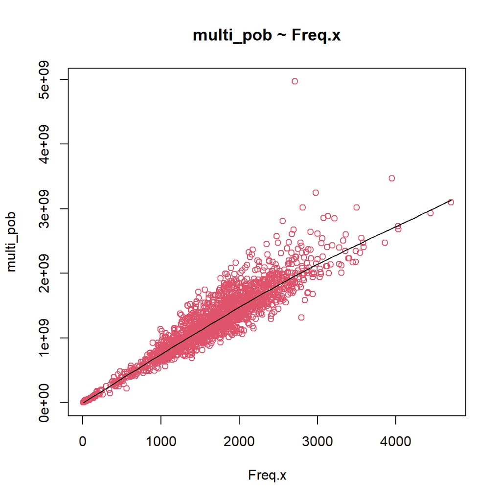

```r
scatter.smooth(x=comunas_censo_casen$Freq.x, y=comunas_censo_casen$multipob, main="multi_pob ~ Freq.x",
     xlab = "Freq.x",
     ylab = "multi_pob",
           col = 2)
```

## 3.2 Outliers

Hemos demostrado en el punto 5.7.2 de [aquí](https://rpubs.com/dataintelligence/expansion_viviendas_001) que la exclusión de ouliers no genera ninguna mejora en el modelo de regresión.

## 3.3 Modelo lineal

Aplicaremos un análisis de regresión lineal del ingreso expandido por zona sobre las frecuencias de respuestas zonales.

```r
linearMod <- lm( multipob~(Freq.x) , data=comunas_censo_casen)
summary(linearMod)
```

```
##
## Call:
## lm(formula = multipob ~ (Freq.x), data = comunas_censo_casen)
##
## Residuals:
##        Min         1Q     Median         3Q        Max
## -768967953 -108156266  -27643807   79749648 2948244359
##
## Coefficients:
##             Estimate Std. Error t value Pr(>|t|)
## (Intercept) 25886538   12103703   2.139   0.0326 *
## Freq.x        737173       6812 108.224   <2e-16 ***
## ---
## Signif. codes:  0 '***' 0.001 '**' 0.01 '*' 0.05 '.' 0.1 ' ' 1
##
## Residual standard error: 196100000 on 1912 degrees of freedom
## Multiple R-squared:  0.8597, Adjusted R-squared:  0.8596
## F-statistic: 1.171e+04 on 1 and 1912 DF,  p-value: < 2.2e-16
```

## 3.4 Gráfica de la recta de regresión lineal

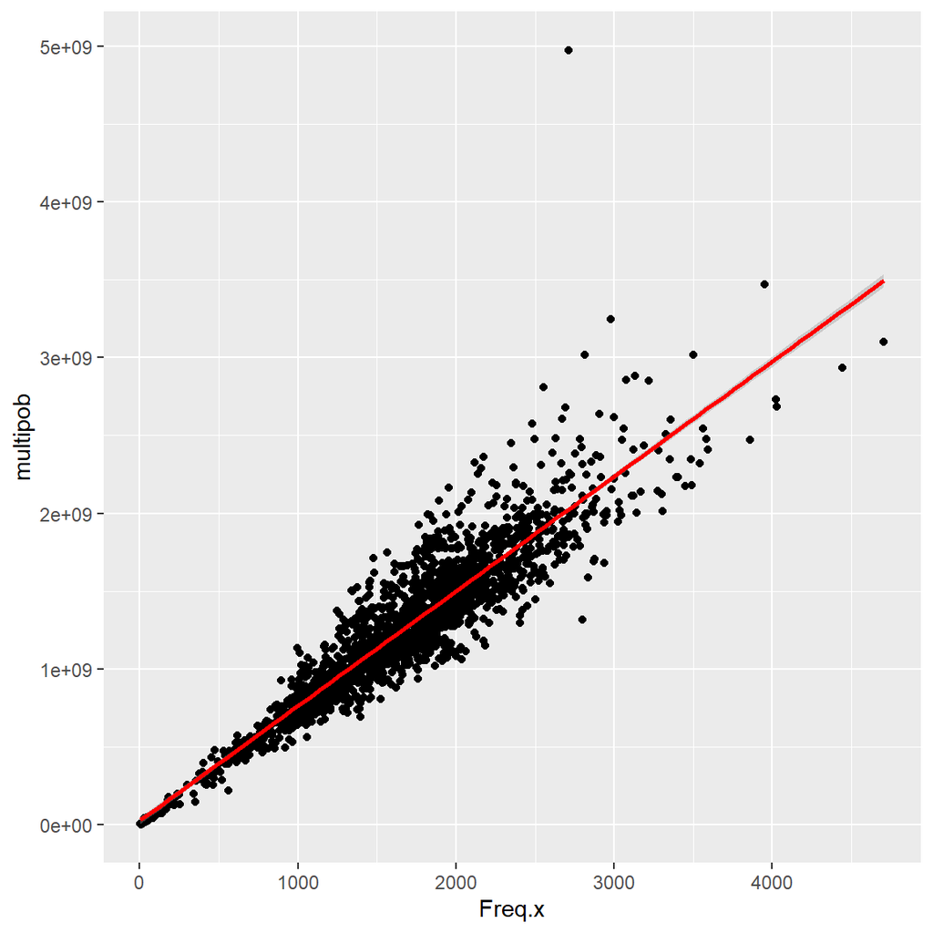

```r
ggplot(comunas_censo_casen, aes(x = Freq.x , y = multipob)) +
  geom_point() +
  stat_smooth(method = "lm", col = "red")
```

# 4 Modelos alternativos

```r
### 8.1 Modelo cuadrático

linearMod <- lm( multipob~(Freq.x^2) , data=comunas_censo_casen)
datos <- summary(linearMod)
dato <- datos$adj.r.squared
modelo <- "cuadrático"
sintaxis <- "linearMod <- lm( multi_pob~(Freq.x^2) , data=h_y_m_comuna_corr_01)"

modelos1 <- cbind(modelo,dato,sintaxis)


modelos1 <- cbind(modelo,dato,sintaxis)

### 8.2 Modelo cúbico

linearMod <- lm( multipob~(Freq.x^3) , data=comunas_censo_casen)
datos <- summary(linearMod)
dato <- datos$adj.r.squared
modelo <- "cúbico"
sintaxis <- "linearMod <- lm( multi_pob~(Freq.x^3) , data=h_y_m_comuna_corr_01)"

modelos2 <- cbind(modelo,dato,sintaxis)

### 8.3 Modelo logarítmico

linearMod <- lm( multipob~log(Freq.x) , data=comunas_censo_casen)
datos <- summary(linearMod)
dato <- datos$adj.r.squared
modelo <- "logarítmico"
sintaxis <- "linearMod <- lm( multi_pob~log(Freq.x) , data=h_y_m_comuna_corr_01)"

modelos3 <- cbind(modelo,dato,sintaxis)

### 8.5 Modelo con raíz cuadrada

linearMod <- lm( multipob~sqrt(Freq.x) , data=comunas_censo_casen)
datos <- summary(linearMod)
dato <- datos$adj.r.squared
modelo <- "raíz cuadrada"
sintaxis <- "linearMod <- lm( multi_pob~sqrt(Freq.x) , data=h_y_m_comuna_corr_01)"

modelos5 <- cbind(modelo,dato,sintaxis)

### 8.6 Modelo raíz-raíz

linearMod <- lm( sqrt(multipob)~sqrt(Freq.x) , data=comunas_censo_casen)
datos <- summary(linearMod)
dato <- datos$adj.r.squared
modelo <- "raíz-raíz"
sintaxis <- "linearMod <- lm( sqrt(multi_pob)~sqrt(Freq.x) , data=h_y_m_comuna_corr_01)"

modelos6 <- cbind(modelo,dato,sintaxis)

### 8.7 Modelo log-raíz

linearMod <- lm( log(multipob)~sqrt(Freq.x) , data=comunas_censo_casen)
datos <- summary(linearMod)
dato <- datos$adj.r.squared
modelo <- "log-raíz"
sintaxis <- "linearMod <- lm( log(multi_pob)~sqrt(Freq.x) , data=h_y_m_comuna_corr_01)"

modelos7 <- cbind(modelo,dato,sintaxis)

### 8.8 Modelo raíz-log

linearMod <- lm( sqrt(multipob)~log(Freq.x) , data=comunas_censo_casen)
datos <- summary(linearMod)
dato <- datos$adj.r.squared
modelo <- "raíz-log"
sintaxis <- "linearMod <- lm( sqrt(multi_pob)~log(Freq.x) , data=h_y_m_comuna_corr_01)"

modelos8 <- cbind(modelo,dato,sintaxis)

### 8.9 Modelo log-log

linearMod <- lm( log(multipob)~log(Freq.x) , data=comunas_censo_casen)
datos <- summary(linearMod)
dato <- datos$adj.r.squared
modelo <- "log-log"
sintaxis <- "linearMod <- lm( log(multi_pob)~log(Freq.x) , data=h_y_m_comuna_corr_01)"

modelos9 <- cbind(modelo,dato,sintaxis)

modelos_bind <- rbind(modelos1, modelos2,modelos3,modelos5,modelos6,modelos7,modelos8,modelos9)
modelos_bind <- as.data.frame(modelos_bind)

modelos_bind <<- modelos_bind[order(modelos_bind$dato, decreasing = T ),]
h_y_m_comuna_corr_01 <<- comunas_censo_casen

kbl(modelos_bind) %>%
  kable_styling(bootstrap_options = c("striped", "hover")) %>%
  kable_paper() %>%
  scroll_box(width = "100%", height = "300px")
```

|  | modelo | dato | sintaxis |
| --- | --- | --- | --- |
| 8 | log-log | 0.965984921527019 | linearMod <- lm( log(multi_pob)~log(Freq.x) , data=h_y_m_comuna_corr_01) |
| 5 | raíz-raíz | 0.915810720684728 | linearMod <- lm( sqrt(multi_pob)~sqrt(Freq.x) , data=h_y_m_comuna_corr_01) |
| 1 | cuadrático | 0.85959140440071 | linearMod <- lm( multi_pob~(Freq.x^2) , data=h_y_m_comuna_corr_01) |
| 2 | cúbico | 0.85959140440071 | linearMod <- lm( multi_pob~(Freq.x^3) , data=h_y_m_comuna_corr_01) |
| 6 | log-raíz | 0.828608203771418 | linearMod <- lm( log(multi_pob)~sqrt(Freq.x) , data=h_y_m_comuna_corr_01) |
| 4 | raíz cuadrada | 0.818966561568705 | linearMod <- lm( multi_pob~sqrt(Freq.x) , data=h_y_m_comuna_corr_01) |
| 7 | raíz-log | 0.80825500426733 | linearMod <- lm( sqrt(multi_pob)~log(Freq.x) , data=h_y_m_comuna_corr_01) |
| 3 | logarítmico | 0.601527019381406 | linearMod <- lm( multi_pob~log(Freq.x) , data=h_y_m_comuna_corr_01) |

# 5 Elección del modelo.

Elegimos el modelo log-log (8) pues tiene el más alto $R^2 (0.966)$

```r
h_y_m_comuna_corr <- h_y_m_comuna_corr_01
metodo <- 8
switch (metodo,
        case = linearMod <- lm( multipob~(Freq.x^2) , data=h_y_m_comuna_corr),
        case = linearMod <- lm( multipob~(Freq.x^3) , data=h_y_m_comuna_corr),
        case = linearMod <- lm( multipob~log(Freq.x) , data=h_y_m_comuna_corr),
        case = linearMod <- lm( multipob~sqrt(Freq.x) , data=h_y_m_comuna_corr),
        case = linearMod <- lm( sqrt(multipob)~sqrt(Freq.x) , data=h_y_m_comuna_corr),
        case = linearMod <- lm( log(multipob)~sqrt(Freq.x) , data=h_y_m_comuna_corr),
        case = linearMod <- lm( sqrt(multipob)~log(Freq.x) , data=h_y_m_comuna_corr),
        case = linearMod <- lm( log(multipob)~log(Freq.x) , data=h_y_m_comuna_corr)
)
summary(linearMod)
```

```
##
## Call:
## lm(formula = log(multipob) ~ log(Freq.x), data = h_y_m_comuna_corr)
##
## Residuals:
##      Min       1Q   Median       3Q      Max
## -0.79100 -0.09181 -0.01093  0.08195  0.88476
##
## Coefficients:
##              Estimate Std. Error t value Pr(>|t|)
## (Intercept) 13.312262   0.032180   413.7   <2e-16 ***
## log(Freq.x)  1.028448   0.004412   233.1   <2e-16 ***
## ---
## Signif. codes:  0 '***' 0.001 '**' 0.01 '*' 0.05 '.' 0.1 ' ' 1
##
## Residual standard error: 0.1449 on 1912 degrees of freedom
## Multiple R-squared:  0.966,  Adjusted R-squared:  0.966
## F-statistic: 5.433e+04 on 1 and 1912 DF,  p-value: < 2.2e-16
```

## 5.1 Modelo log-log (**log-log**)

### 5.1.1 Diagrama de dispersión y lm sobre **log-log**

Desplegamos una curva suavizada por loess en el diagrama de dispersión.

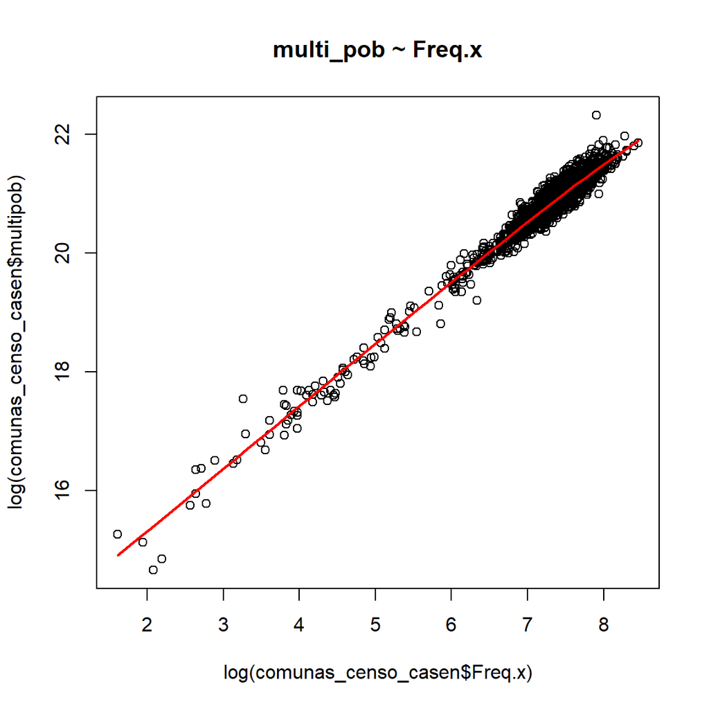

```r
scatter.smooth(x=log(comunas_censo_casen$Freq.x), y=log(comunas_censo_casen$multipob), lpars = list(col = "red", lwd = 2, lty = 1), main="multi_pob ~ Freq.x")
```

Desplegamos la curva de regresión con sus intervalos de confianza al 95%:

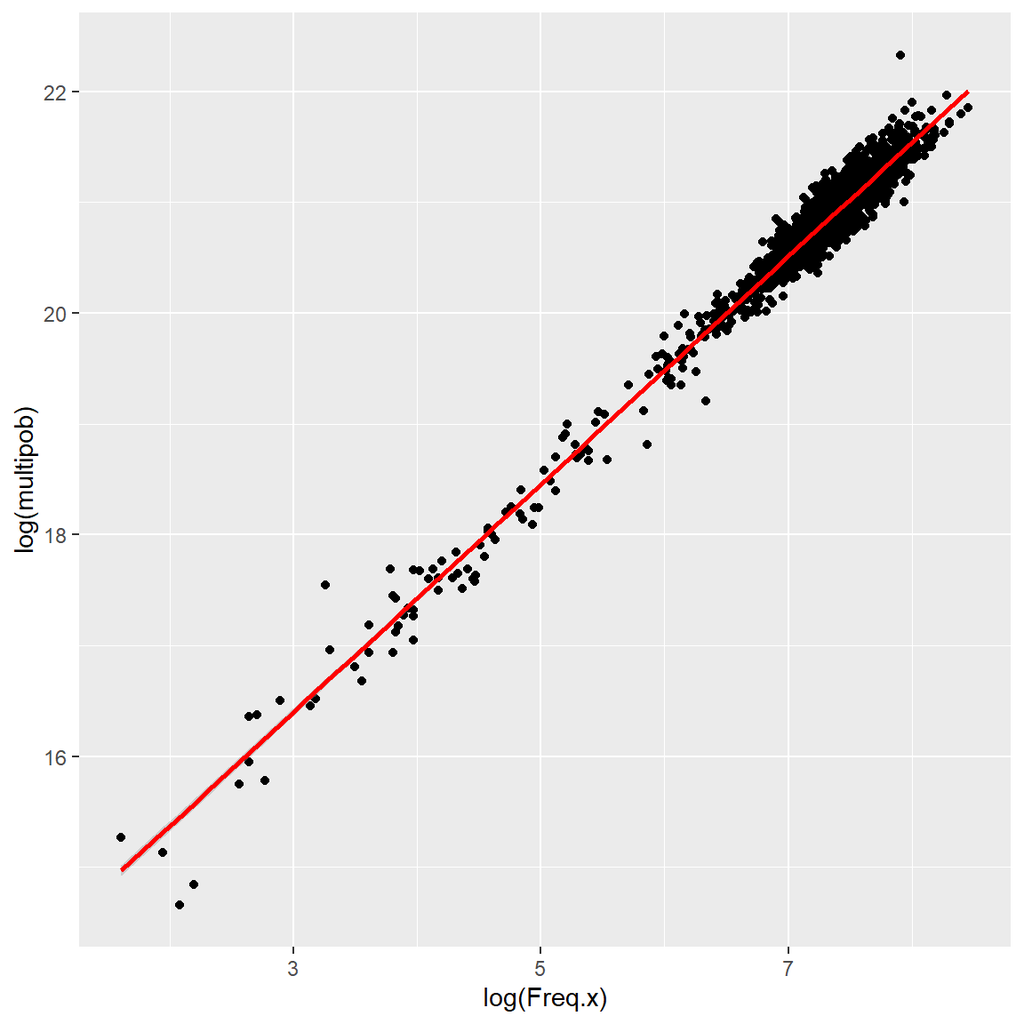

```r
ggplot(comunas_censo_casen, aes(x = log(Freq.x) , y = log(multipob))) + geom_point() + stat_smooth(method = "lm", col = "red")
```

### 5.1.2 Análisis de residuos

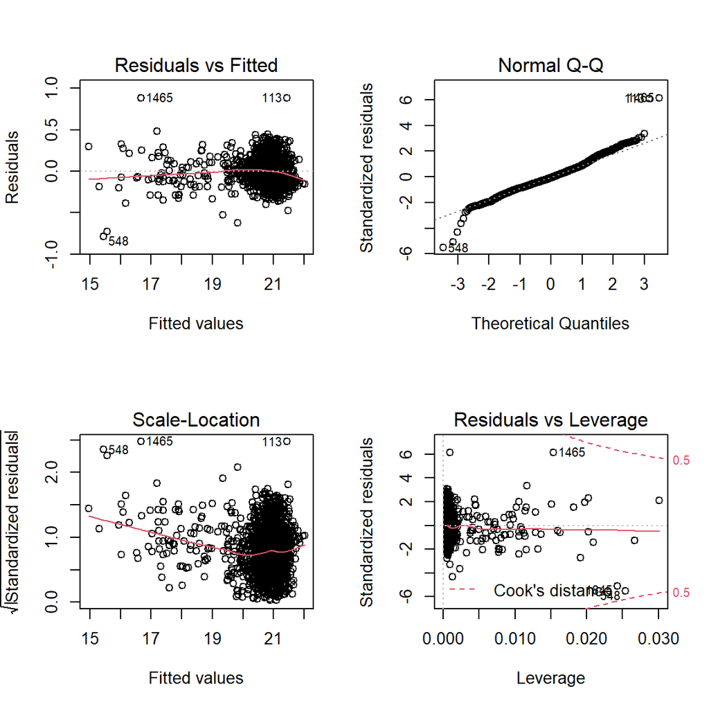

```r
par(mfrow = c (2,2))
plot(linearMod)
```

### 5.1.3 Modelo log-log

$$\hat Y = e^{\beta_0+\beta_1 ln{X}}$$

### 5.1.4 Modelo real:

$$\hat Y = e^{13.312262+1.028448\cdot ln{X}}$$

```r
linearMod <- lm( log(multipob)~log(Freq.x) , data=comunas_censo_casen)
aa <- linearMod$coefficients[1]
bb <- linearMod$coefficients[2]
```

# 6 Aplicación la regresión a los valores de la variable a nivel de zona

Esta nueva variable se llamará: est_ing

```r
comunas_censo_casen$est_ing <- exp(aa+bb*log(comunas_censo_casen$Freq.x))
```

# 7 División del valor estimado entre la población total de la zona para obtener el ingreso medio por zonal

$$Ingreso \_ Medio\_zona = est\_ing / (personas * p\_poblacional)$$

```r
comunas_censo_casen$ing_medio_zona <- comunas_censo_casen$est_ing /(comunas_censo_casen$personas  * comunas_censo_casen$p)
r3_100 <- comunas_censo_casen[c(1:100),]
kbl(r3_100) %>%
  kable_styling(bootstrap_options = c("striped", "hover")) %>%
  kable_paper() %>%
  scroll_box(width = "100%", height = "300px")
```

| zona | código.x | Freq.x | personas | comuna | promedio_i | año | ingresos_expandidos | Freq.y | p | código.y | multipob | est_ing | ing_medio_zona |
| --- | --- | --- | --- | --- | --- | --- | --- | --- | --- | --- | --- | --- | --- |
| 13101011001 | 13101 | 1401 | 404495 | Santiago | 450851.7 | 2017 | 182367246208 | 2174 | 0.0053746 | 13101 | 980151530 | 1040852195 | 478772.9 |
| 13101011002 | 13101 | 1515 | 404495 | Santiago | 450851.7 | 2017 | 182367246208 | 2282 | 0.0056416 | 13101 | 1028843511 | 1128054436 | 494327.1 |
| 13101011003 | 13101 | 1458 | 404495 | Santiago | 450851.7 | 2017 | 182367246208 | 2209 | 0.0054611 | 13101 | 995931339 | 1084429064 | 490914.0 |
| 13101011004 | 13101 | 1171 | 404495 | Santiago | 450851.7 | 2017 | 182367246208 | 1821 | 0.0045019 | 13101 | 821000891 | 865550232 | 475315.9 |
| 13101011005 | 13101 | 1212 | 404495 | Santiago | 450851.7 | 2017 | 182367246208 | 1741 | 0.0043041 | 13101 | 784932757 | 896733045 | 515067.8 |
| 13101021001 | 13101 | 2203 | 404495 | Santiago | 450851.7 | 2017 | 182367246208 | 3448 | 0.0085242 | 13101 | 1554536558 | 1657897120 | 480828.6 |
| 13101021002 | 13101 | 1902 | 404495 | Santiago | 450851.7 | 2017 | 182367246208 | 2856 | 0.0070607 | 13101 | 1287632369 | 1425405774 | 499091.7 |
| 13101021003 | 13101 | 1882 | 404495 | Santiago | 450851.7 | 2017 | 182367246208 | 2768 | 0.0068431 | 13101 | 1247957422 | 1409993205 | 509390.6 |
| 13101021004 | 13101 | 2114 | 404495 | Santiago | 450851.7 | 2017 | 182367246208 | 3279 | 0.0081064 | 13101 | 1478342626 | 1589053715 | 484615.3 |
| 13101021005 | 13101 | 1392 | 404495 | Santiago | 450851.7 | 2017 | 182367246208 | 2258 | 0.0055823 | 13101 | 1018023071 | 1033976195 | 457916.8 |
| 13101021006 | 13101 | 1690 | 404495 | Santiago | 450851.7 | 2017 | 182367246208 | 2478 | 0.0061262 | 13101 | 1117210438 | 1262276972 | 509393.5 |
| 13101021007 | 13101 | 1541 | 404495 | Santiago | 450851.7 | 2017 | 182367246208 | 2326 | 0.0057504 | 13101 | 1048680984 | 1147969349 | 493538.0 |
| 13101021008 | 13101 | 981 | 404495 | Santiago | 450851.7 | 2017 | 182367246208 | 1541 | 0.0038097 | 13101 | 694762423 | 721468050 | 468181.7 |
| 13101031001 | 13101 | 1607 | 404495 | Santiago | 450851.7 | 2017 | 182367246208 | 2313 | 0.0057182 | 13101 | 1042819912 | 1198565178 | 518186.4 |
| 13101031002 | 13101 | 4031 | 404495 | Santiago | 450851.7 | 2017 | 182367246208 | 5950 | 0.0147097 | 13101 | 2682567436 | 3086174768 | 518684.8 |
| 13101031003 | 13101 | 3392 | 404495 | Santiago | 450851.7 | 2017 | 182367246208 | 4955 | 0.0122498 | 13101 | 2233970024 | 2584230250 | 521539.9 |
| 13101031004 | 13101 | 2431 | 404495 | Santiago | 450851.7 | 2017 | 182367246208 | 3903 | 0.0096491 | 13101 | 1759674068 | 1834614247 | 470052.3 |
| 13101031005 | 13101 | 1092 | 404495 | Santiago | 450851.7 | 2017 | 182367246208 | 1791 | 0.0044277 | 13101 | 807475341 | 805554781 | 449779.3 |
| 13101031006 | 13101 | 1141 | 404495 | Santiago | 450851.7 | 2017 | 182367246208 | 1697 | 0.0041954 | 13101 | 765095284 | 842753151 | 496613.5 |
| 13101031007 | 13101 | 1855 | 404495 | Santiago | 450851.7 | 2017 | 182367246208 | 2973 | 0.0073499 | 13101 | 1340382015 | 1389193635 | 467270.0 |
| 13101041001 | 13101 | 1549 | 404495 | Santiago | 450851.7 | 2017 | 182367246208 | 2790 | 0.0068975 | 13101 | 1257876159 | 1154098946 | 413655.5 |
| 13101041002 | 13101 | 1496 | 404495 | Santiago | 450851.7 | 2017 | 182367246208 | 2668 | 0.0065959 | 13101 | 1202872255 | 1113507368 | 417356.6 |
| 13101041003 | 13101 | 1565 | 404495 | Santiago | 450851.7 | 2017 | 182367246208 | 2729 | 0.0067467 | 13101 | 1230374207 | 1166360836 | 427395.0 |
| 13101041004 | 13101 | 1689 | 404495 | Santiago | 450851.7 | 2017 | 182367246208 | 2828 | 0.0069914 | 13101 | 1275008522 | 1261508821 | 446078.1 |
| 13101041005 | 13101 | 1532 | 404495 | Santiago | 450851.7 | 2017 | 182367246208 | 2550 | 0.0063042 | 13101 | 1149671758 | 1141074635 | 447480.2 |
| 13101051001 | 13101 | 1781 | 404495 | Santiago | 450851.7 | 2017 | 182367246208 | 3135 | 0.0077504 | 13101 | 1413419985 | 1332231918 | 424954.4 |
| 13101051002 | 13101 | 2544 | 404495 | Santiago | 450851.7 | 2017 | 182367246208 | 4424 | 0.0109371 | 13101 | 1994567788 | 1922375597 | 434533.4 |
| 13101051003 | 13101 | 1299 | 404495 | Santiago | 450851.7 | 2017 | 182367246208 | 2355 | 0.0058221 | 13101 | 1061755683 | 962999736 | 408917.1 |
| 13101061001 | 13101 | 2301 | 404495 | Santiago | 450851.7 | 2017 | 182367246208 | 3968 | 0.0098098 | 13101 | 1788979426 | 1733793703 | 436944.0 |
| 13101061002 | 13101 | 2465 | 404495 | Santiago | 450851.7 | 2017 | 182367246208 | 4747 | 0.0117356 | 13101 | 2140192877 | 1861008352 | 392038.8 |

[output cut: 70 more lines]

Guardamos:

```r
saveRDS(comunas_censo_casen, "URBANO/region_13_P17_u.rds")
```

# 8 Referencias

https://rpubs.com/osoramirez/316691

https://dataintelligencechile.shinyapps.io/casenfinal

Manual_de_usuario_Censo_2017_16R.pdf

http://www.censo2017.cl/microdatos/

Censo de Población y Vivienda

https://www.ine.cl/estadisticas/sociales/censos-de-poblacion-y-vivienda/poblacion-y-vivienda

http://r-statistics.co/Linear-Regression.html

# 9 Anexo:

## 9.1 Modelos alternativos

### 9.1.1 Modelo cuadrático

$$\hat Y = \beta_0 + \beta_1 X^2$$

### 9.1.2 Modelo cúbico

$$\hat Y = \beta_0 + \beta_1 X^3$$

### 9.1.3 Modelo logarítmico

$$\hat Y = \beta_0 + \beta_1 ln X$$

### 9.1.4 Modelo exponencial

$$\hat Y = \beta_0 + \beta_1 e^X$$

No es aplicable sin una transformación pues los valores elevados a $e$ de Freq.x tienden a infinito.

### 9.1.5 Modelo con raíz cuadrada

$$\hat Y = \beta_0 + \beta_1 \sqrt {X}$$

### 9.1.6 raiz raiz

$$\hat Y = {\beta_0}^2 + 2 \beta_0 \beta_1 \sqrt{X}+ \beta_1^2 X$$

### 9.1.7 Modelo log-raíz

$$\hat Y = e^{\beta_0 + \beta_1 \sqrt{X}}$$

### 9.1.8 Modelo raíz-log

$$\hat Y = {\beta_0}^2 + 2 \beta_0 \beta_1 \ln{X}+ \beta_1^2 ln^2X$$

### 9.1.9 Modelo log-log

$$\hat Y = e^{\beta_0+\beta_1 ln{X}}$$